# Análisis Exploratorio y Modelo de Clasificación en el Dataset de Netflix

## Introducción y Planteamiento del Problema

El consumo de contenido en plataformas de streaming ha transformado la industria del entretenimiento, generando volúmenes masivos de datos diarios. El presente proyecto tiene como objetivo aplicar una metodología sistemática de Minería de Datos sobre el conjunto de datos de títulos de Netflix. A través de este análisis, se busca identificar patrones estructurales en el catálogo histórico de la plataforma y construir un modelo predictivo capaz de clasificar el tipo de producción.

El problema analítico se aborda como una tarea de aprendizaje supervisado (clasificación binaria). Utilizando características intrínsecas de las producciones —como el año de lanzamiento original, el año de adición a la plataforma y la diversidad de géneros asignados—, se entrenará un clasificador matemático para estimar la probabilidad de que un registro corresponda a una Película (Movie) en lugar de una Serie de Televisión (TV Show).

## Metodología del Proceso

Para garantizar el rigor estadístico y técnico, el desarrollo del notebook se estructurará bajo el siguiente flujo de trabajo:

1. Ingesta y Entendimiento de Datos: Mapeo de la estructura matricial, dimensiones y tipos de variables del dataset original.
2. Auditoría de Calidad: Diagnóstico y cuantificación de inconsistencias, registros duplicados y vectores con valores faltantes(NaN).
3. Preprocesamiento y Limpieza: Aplicación de estrategias de imputación categórica controlada y transformaciones de tipos de datos para asegurar la integridad analítica.
4. Ingeniería de Variables (Feature Engineering): Extracción de nuevos atributos numéricos (predictores) y codificación formal de la variable objetivo binaria.
5. Análisis Exploratorio de Datos Visual (EDA): Examinación de distribuciones de frecuencia, comportamientos temporales y dispersión mediante gráficos estadísticos (Seaborn/Matplotlib).
6. Modelado Predictivo y Escalado: Partición del dataset en conjuntos de entrenamiento y validación, estandarización Z-score de las características y ajuste de un algoritmo de Regresión Logística.
7. Evaluación Metrológica: Interpretación matemática de los coeficientes obtenidos ($\beta$) y validación del rendimiento del modelo mediante matrices de confusión y métricas de clasificación (Accuracy, Precision, Recall y F1-Score).

## 1. Cargar y Entender la Tabla

Descripción: Antes de realizar cualquier manipulación en el dataset, es fundamental realizar una fase de exploración inicial para conocer la estructura de los datos. Esto incluye identificar las dimensiones de la matriz de datos (filas y columnas), revisar las primeras instancias para comprender el contexto de las variables y analizar los tipos de datos asignados automáticamente por Pandas para detectar posibles discrepancias técnicas.

```python
!pip install matplotlib seaborn
import pandas as pd
import numpy as np
import matplotlib.pyplot as plt
import seaborn as sns

# Cargar el dataset desde la carpeta de datos del proyecto
df_netflix = pd.read_csv("data/netflix_titles.csv")

# 1.1 Visualización de las primeras instancias para inspección visual rápida
print("--- Primeras 3 filas del dataset ---")
display(df_netflix.head(3))

# 1.2 Dimensiones del DataFrame (Instancias vs Variables)
print(f"\nDimensiones del dataset -> Filas: {df_netflix.shape[0]}, Columnas: {df_netflix.shape[1]}\n")

# 1.3 Tipos de datos oficiales y conteo inicial de registros no nulos
print("--- Resumen estructural del DataFrame (info) ---")
df_netflix.info()
```

```
--- Primeras 3 filas del dataset ---
```

|  | show_id | type | title | director | cast | country | date_added | release_year | rating | duration | listed_in | description |
| --- | --- | --- | --- | --- | --- | --- | --- | --- | --- | --- | --- | --- |
| 0 | s1 | Movie | Dick Johnson Is Dead | Kirsten Johnson | NaN | United States | September 25, 2021 | 2020 | PG-13 | 90 min | Documentaries | As her father nears the end of his life, filmm... |
| 1 | s2 | TV Show | Blood & Water | NaN | Ama Qamata, Khosi Ngema, Gail Mabalane, Thaban... | South Africa | September 24, 2021 | 2021 | TV-MA | 2 Seasons | International TV Shows, TV Dramas, TV Mysteries | After crossing paths at a party, a Cape Town t... |
| 2 | s3 | TV Show | Ganglands | Julien Leclercq | Sami Bouajila, Tracy Gotoas, Samuel Jouy, Nabi... | NaN | September 24, 2021 | 2021 | TV-MA | 1 Season | Crime TV Shows, International TV Shows, TV Act... | To protect his family from a powerful drug lor... |

```
Dimensiones del dataset -> Filas: 8807, Columnas: 12

--- Resumen estructural del DataFrame (info) ---
<class 'pandas.DataFrame'>
RangeIndex: 8807 entries, 0 to 8806
Data columns (total 12 columns):
 #   Column        Non-Null Count  Dtype
---  ------        --------------  -----
 0   show_id       8807 non-null   str
 1   type          8807 non-null   str
 2   title         8807 non-null   str
 3   director      6173 non-null   str
 4   cast          7982 non-null   str
 5   country       7976 non-null   str
 6   date_added    8797 non-null   str
 7   release_year  8807 non-null   int64
 8   rating        8803 non-null   str
 9   duration      8804 non-null   str
 10  listed_in     8807 non-null   str
 11  description   8807 non-null   str
dtypes: int64(1), str(11)
memory usage: 825.8 KB
```

## 2. Detectar Problemas de Calidad de Datos

Descripción: La calidad de los datos determina la confiabilidad de cualquier modelo predictivo. En esta fase se realiza una auditoría diagnóstica para cuantificar dos de los problemas más comunes en la minería de datos: la presencia de registros completamente duplicados (que generan sesgos de sobreajuste) y la existencia de valores faltantes (NaN o nulos), los cuales requieren una estrategia de imputación o eliminación controlada en los siguientes pasos.

```python
# 2.1 Identificación y conteo de filas completamente duplicadas
duplicados = df_netflix.duplicated().sum()
print(f"Cantidad de registros completamente duplicados detectados: {duplicados}")

# 2.2 Cuantificación de valores faltantes (nulos) por cada variable
print("\nConteo de valores nulos por columna:")
display(df_netflix.isnull().sum().to_frame("Total Nulos"))

# 2.3 Verificación de la consistencia en la variable categórica objetivo (type)
print("\nCategorías únicas presentes en la variable 'type':")
print(df_netflix["type"].unique())
```

```
Cantidad de registros completamente duplicados detectados: 0

Conteo de valores nulos por columna:
```

|  | Total Nulos |
| --- | --- |
| show_id | 0 |
| type | 0 |
| title | 0 |
| director | 2634 |
| cast | 825 |
| country | 831 |
| date_added | 10 |
| release_year | 0 |
| rating | 4 |
| duration | 3 |
| listed_in | 0 |
| description | 0 |

```
Categorías únicas presentes en la variable 'type':
<StringArray>
['Movie', 'TV Show']
Length: 2, dtype: str
```

## 3. Limpieza de Valores Faltantes y Corrección de Tipos

Descripción: Para evitar la pérdida masiva de datos numéricos o históricos, se aplica una estrategia de imputación categórica en variables como director, cast y country, sustituyendo los valores nulos por etiquetas genéricas ("Unknown"/"No Director"). Las filas con nulos en variables de bajo impacto faltante (rating y duration) se eliminan para mantener la integridad del set.

Asimismo, se detecta que date_added se importó como texto (object). Para poder explotar su valor temporal, se limpian los espacios en blanco residuales mediante .str.strip() y se transforma formalmente a un tipo de dato Datetime.

```python
# Crear una copia de seguridad para iniciar el proceso de transformación limpia
df_clean = df_netflix.copy()

# 3.1 Imputación de variables categóricas con valores genéricos placeholders
df_clean["director"] = df_clean["director"].fillna("No Director")
df_clean["cast"] = df_clean["cast"].fillna("Unknown Cast")
df_clean["country"] = df_clean["country"].fillna("Unknown Country")

# 3.2 Eliminación dirigida de registros con nulos en columnas críticas minoritarias
df_clean = df_clean.dropna(subset=["rating", "duration"])

# 3.3 Transformación de tipo de dato: Texto (String) a Temporal (Datetime)
df_clean["date_added"] = df_clean["date_added"].str.strip()
df_clean["date_added"] = pd.to_datetime(df_clean["date_added"], format="%B %d, %Y", errors='coerce')

# Validación final: El conteo total de nulos en la matriz debe reducirse drásticamente
print(f"Validación post-limpieza -> Nulos totales remanentes en la tabla: {df_clean.isnull().sum().sum()}")
```

```
Validación post-limpieza -> Nulos totales remanentes en la tabla: 10
```

## 4. Ingeniería de Variables (Feature Engineering)

Descripción: En esta etapa se transforman las variables existentes o se extraen nuevos atributos numéricos que faciliten patrones más claros para el algoritmo de aprendizaje automático. Para este análisis, realizaremos tres operaciones:

Extraer el año específico en el que el título fue agregado a la plataforma (year_added) a partir de la variable temporal calculada en el paso anterior.

Cuantificar la complejidad categórica de cada título contando cuántos géneros tiene asignados en la columna listed_in (separados por comas).

Definir la variable objetivo binaria (is_movie): tomará el valor de 1 si el título es una Película (Movie) y 0 si es una Serie (TV Show), preparando así nuestro escenario de clasificación.

```python
# 4.1 Extraer el año de adición a la plataforma
df_clean["year_added"] = df_clean["date_added"].dt.year

# 4.2 Calcular la cantidad de géneros asignados por título
# Se divide la cadena por comas y se mide la longitud de la lista resultante
df_clean["num_genres"] = df_clean["listed_in"].apply(lambda x: len(str(x).split(",")))

# 4.3 Codificación binaria de la variable objetivo (Target)
df_clean["is_movie"] = (df_clean["type"] == "Movie").astype(int)

# Visualización de la nueva estructura de características (Features)
print("--- Nuevas variables construidas para el modelado ---")
display(df_clean[["type", "is_movie", "year_added", "num_genres"]].head(3))
```

```
--- Nuevas variables construidas para el modelado ---
```

|  | type | is_movie | year_added | num_genres |
| --- | --- | --- | --- | --- |
| 0 | Movie | 1 | 2021.0 | 1 |
| 1 | TV Show | 0 | 2021.0 | 3 |
| 2 | TV Show | 0 | 2021.0 | 3 |

## 5. Análisis Exploratorio de Datos Visual (EDA)

Descripción: La exploración gráfica nos permite validar hipótesis estadísticas e identificar sesgos en la distribución de las variables antes de entrenar el modelo. En esta sección analizaremos la evolución histórica de lanzamientos acumulados por tipo de contenido para entender el comportamiento temporal, y utilizaremos diagramas de caja (Boxplots) para evaluar si la cantidad de géneros asignados difiere significativamente entre Películas y Series de televisión.

## Evolución Histórica de la Producción de Contenido por Tipo de Catálogo

```
--- Frecuencia absoluta por Tipo de Contenido ---
```

| type | count |
| --- | --- |
| Movie | 6126 |
| TV Show | 2674 |

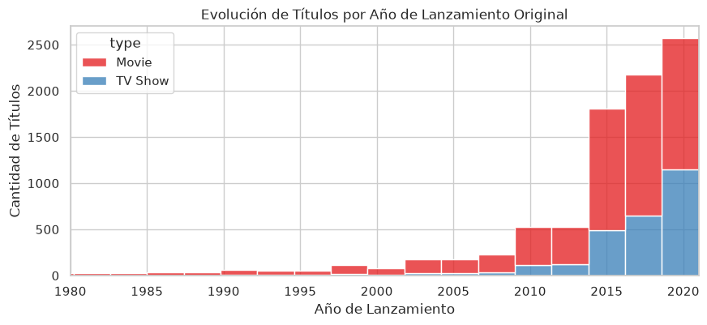

```python
# Configuración global del estilo estético de los gráficos
sns.set_theme(style="whitegrid")

# 5.1 Distribución de frecuencias de la variable objetivo
print("--- Frecuencia absoluta por Tipo de Contenido ---")
display(df_clean["type"].value_counts().to_frame())

# 5.2 Gráfico 1: Histograma de la evolución histórica de lanzamientos
plt.figure(figsize=(10, 4))
sns.histplot(data=df_clean, x="release_year", hue="type", multiple="stack", bins=40, palette="Set1")
plt.title("Evolución de Títulos por Año de Lanzamiento Original")
plt.xlabel("Año de Lanzamiento")
plt.ylabel("Cantidad de Títulos")
plt.xlim(1980, 2021)  # Acotamos el eje X para observar la zona de mayor densidad de datos
plt.show()
```

## Análisis Comparativo del Número de Géneros Asignados: Películas vs. Series

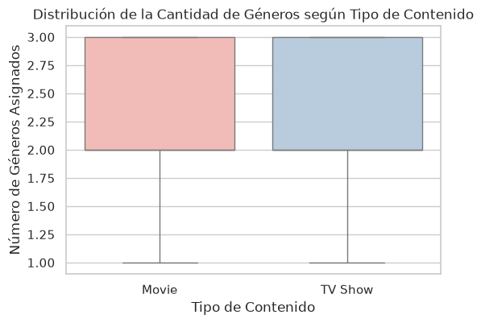

```python
# 5.3 Gráfica 2: Diagrama de caja (Boxplot) corregido sin advertencias
plt.figure(figsize=(6, 4))
# Asignamos 'x' a 'hue' y desactivamos la leyenda para mantener el diseño limpio
sns.boxplot(data=df_clean, x="type", y="num_genres", hue="type", palette="Pastel1", legend=False)
plt.title("Distribución de la Cantidad de Géneros según Tipo de Contenido")
plt.xlabel("Tipo de Contenido")
plt.ylabel("Número de Géneros Asignados")
plt.show()
```

## 6. Construcción, Escalado e Interpretación del Modelo Logístico

Descripción: El objetivo matemático es entrenar un clasificador estadístico mediante Regresión Logística para estimar la probabilidad de que un título sea una película (is_movie = 1) con base en tres predictores numéricos: release_year, num_genres y year_added. Para asegurar un entrenamiento riguroso siguiendo buenas prácticas de minería de datos, el proceso se divide en:

1. Remoción de registros incompletos: Se eliminan filas con nulos específicos generados en la conversión de fechas para evitar errores matriciales.
2. Partición del dataset: Se segmentan los datos en un set de entrenamiento (80%) y uno de prueba (20%) para evaluar la capacidad de generalización del modelo.
3. Estandarización (Scaling): Dado que las escalas numéricas difieren significativamente (los años se mueven en miles y los géneros en unidades individuales), se aplica un escalado estándar Z-score para evitar que variables con magnitudes grandes distorsionen el cálculo de los pesos.
4. Análisis de Coeficientes: Se extraen los coeficientes calculados ($\beta$) para interpretar el impacto logarítmico de cada variable sobre la probabilidad final.
5. Evaluación de Rendimiento: Se genera la matriz de confusión y el reporte formal de clasificación (Precisión, Exhaustividad y F1-Score).

```
=== 1. INTERPRETACIÓN DE COEFICIENTES DEL MODELO ===
Intercepto (Beta 0): 0.1031
Variable 'release_year' (Beta): Coeficiente = -0.7075
Variable 'num_genres' (Beta): Coeficiente = -0.1987
Variable 'year_added' (Beta): Coeficiente = 0.0662

Nota: Coeficientes positivos aumentan la probabilidad de ser 'Movie'; negativos la disminuyen.

=== 2. MATRICES Y MÉTRICAS DE RENDIMIENTO ===
Exactitud Global del Modelo (Accuracy): 55.75%

Reporte de Clasificación Estructurado:
              precision    recall  f1-score   support

     TV Show       0.38      0.72      0.49       531
       Movie       0.80      0.49      0.61      1227

    accuracy                           0.56      1758
   macro avg       0.59      0.60      0.55      1758
weighted avg       0.67      0.56      0.57      1758
```

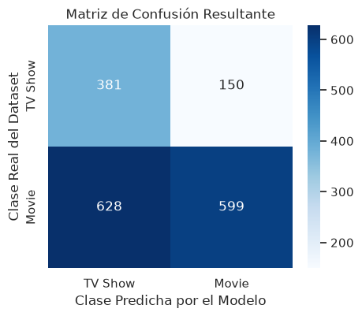

```python
!pip install scikit-learn
from sklearn.model_selection import train_test_split
from sklearn.linear_model import LogisticRegression
from sklearn.preprocessing import StandardScaler
from sklearn.metrics import classification_report, confusion_matrix, accuracy_score

# 6.1 Tratamiento final de nulos en variables predictoras y selección de matrices
df_model = df_clean.dropna(subset=["year_added"])
X = df_model[["release_year", "num_genres", "year_added"]]
y = df_model["is_movie"]

# 6.2 División del conjunto de datos (80% Entrenamiento, 20% Validación)
X_train, X_test, y_train, y_test = train_test_split(X, y, test_size=0.2, random_state=42)

# 6.3 Estandarización de características utilizando StandardScaler (Z-score)
scaler = StandardScaler()
X_train_scaled = scaler.fit_transform(X_train)
X_test_scaled = scaler.transform(X_test)

# 6.4 Inicialización con balanceo de clases (class_weight='balanced') para evitar el sesgo
modelo_log = LogisticRegression(class_weight='balanced', random_state=42)
modelo_log.fit(X_train_scaled, y_train)

# 6.5 Generación de predicciones probabilísticas sobre el conjunto de test
y_pred = modelo_log.predict(X_test_scaled)

# --- REPORTE METROLÓGICO Y DE COEFICIENTES ---
print("=== 1. INTERPRETACIÓN DE COEFICIENTES DEL MODELO ===")
print(f"Intercepto (Beta 0): {modelo_log.intercept_[0]:.4f}")
for col, coef in zip(X.columns, modelo_log.coef_[0]):
    print(f"Variable '{col}' (Beta): Coeficiente = {coef:.4f}")
print("\nNota: Coeficientes positivos aumentan la probabilidad de ser 'Movie'; negativos la disminuyen.\n")

print("=== 2. MATRICES Y MÉTRICAS DE RENDIMIENTO ===")
print(f"Exactitud Global del Modelo (Accuracy): {accuracy_score(y_test, y_pred):.2%}\n")
print("Reporte de Clasificación Estructurado:")
# Agregamos zero_division=0 para limpiar el output de advertencias
print(classification_report(y_test, y_pred, target_names=["TV Show", "Movie"], zero_division=0))

# 6.6 Visualización formal de la Matriz de Confusión
matriz = confusion_matrix(y_test, y_pred)
plt.figure(figsize=(5, 4))
sns.heatmap(matriz, annot=True, fmt="d", cmap="Blues", xticklabels=["TV Show", "Movie"], yticklabels=["TV Show", "Movie"])
plt.title("Matriz de Confusión Resultante")
plt.xlabel("Clase Predicha por el Modelo")
plt.ylabel("Clase Real del Dataset")
plt.show()
```

## 7. Interpretación de Resultados y Conclusiones del Modelo

### 7.2 Evaluación de la Matriz de Confusión y Métricas

Al observar el reporte estructurado y la matriz gráfica, podemos extraer las siguientes conclusiones sobre el comportamiento del clasificador:

1. Desbalance en el desempeño de clases: * Para las Películas (Movie), el modelo tiene una alta Precisión (0.80); es decir, cuando el modelo dice que algo es una película, acierta el 80% de las veces. Sin embargo, su Recall (0.49) es bajo, lo que significa que se le están escapando muchas películas reales (clasificó 628 películas reales como si fueran series).
   - Para las Series (TV Show) ocurre lo opuesto. El Recall (0.72) es alto, logrando identificar al 72% de todas las series reales del conjunto de prueba. Pero su Precisión (0.38) es muy baja, lo que indica que genera muchos falsos positivos.
2. Diagnóstico del Rendimiento General: Con una exactitud global del 55.75%, el modelo demuestra que las variables utilizadas (release_year, num_genres, year_added) no contienen la suficiente información o varianza para separar linealmente películas de series con alta precisión.

### 7.3 Propuestas de Mejora

Para incrementar el rendimiento de este modelo en futuras iteraciones de minería de datos, se recomienda:

- Incorporar variables de texto (NLP): Extraer patrones de palabras clave a partir de las columnas title o description usando técnicas como TF-IDF.
- Procesar variables categóricas complejas
- Explorar modelos no lineales: Probar algoritmos más robustos frente a relaciones complejas, tales como Árboles de Decisión o Bosques Aleatorios (Random Forests).